# Demand

Electricity demand is a vital component in the planning, operation, and resilience of power systems. Climate change is expected to alter electricity demand patterns by affecting not only temperature characteristics, such as mean temperature, frequency of temperature extremes, and seasonal variability, but also consumption behaviours across different sectors. Numerous studies project increased cooling demand during hotter summers and reduced heating demand during milder winters as this pattern has been consistently observed across multiple global regions (Amonkar et al. (2023), Auffhammer and Aroonruengsawat (2011), Pilli-Sihvola et al. (2010), Trotter et al. (2016), Wood et al. (2015)).

The magnitude and direction of these changes are strongly dependent on region and latitude. For example, countries in warmer climates are expected to experience higher overall demand growth due to increased cooling loads (Bonkaney et al. (2023), Emodi et al. (2018), Zachariadis and Hadjinicolaou (2014)). Climate change also influences electricity consumption by sector and alters temporal demand profiles, including daily and seasonal variations. The residential, commercial, and industrial sectors respond differently to climate drivers (Dirks et al. (2015), Shaik (2024), Taseska et al. (2012)). Furthermore, the timing of electricity demand is shifting, with studies projecting changes in peak load hours and seasonal peaks due to rising temperatures and more frequent extreme heat events ( Amonkar et al. (2023), Fonseca et al. (2019), Romitti and Sue Wing (2022)).

To assess the impacts of climate change on electricity demand, various approaches have been employed. These include the use of climate projections from General Circulation Models (or Global Climate Models, GCMs) and Regional Climate Models (RCMs), often combined with downscaling techniques to capture local climatic variability (Auffhammer et al. (2017), Auffhammer and Aroonruengsawat (2011), Fonseca et al. (2019), Lipson et al. (2019), Trotter et al. (2016)). Empirical models, such as regression-based analyses, have also been used to estimate historical relationships between temperature and electricity use (Bonkaney et al. (2023), Emodi et al. (2018), Pilli-Sihvola et al. (2010)). Additionally, simulation tools and integrated energy-climate models are applied to explore future scenarios under varying socio-economic and climatic conditions (Dirks et al. (2015), Lipson et al. (2019), Taseska et al. (2012)).

## Climate change drivers and affected electricity demand parameters

### Demand parameters

Electricity demand is governed by a set of interconnected parameters that respond to both climatic and non-climatic factors. Under climate change, demand parameters, such as annual electricity consumption, peak demand magnitude and its timing, and daily load profiles, are increasingly influenced by variations in temperature, precipitation, and extreme weather. Wood et al. (2015) identified key demand parameters affected by climate change as (1) total annual demand, influencing long-term generation capacity, (2) size and timing of peak demand, driving reserve margin and infrastructure sizing, while the shape of the daily load profile provides additional insight into intraday variability and operational flexibility needs, (3) spatial distribution, affecting transmission and distribution network planning, and (4) sectoral response capacity, determining how quickly end-users can adapt to changing thermal comfort needs.

Among all climatic variables, air temperature exerts the strongest impacts on electricity demand. The non-linear V-shaped (or U-shaped) relationship, where demand rises both at high and low temperatures due to cooling and heating needs, respectively, is well presented by using Cooling Degree Days (CDD) and Heating Degree Days (HDD) (Hu et al. (2024), Fonseca et al. (2019), Schaeffer et al. (2012), Garrido-Perez et al. (2021), Hiruta et al. (2022), Auffhammer and Aroonruengsawat (2011), Pilli-Sihvola et al. (2010)). The CDD quantifies the accumulated temperature above a comfort threshold (commmonly 18degC or 65degF), which are mainly correlated with air conditioning demand. The HDD reflects the accumulated temperature below the comfort threshold to estimate electric heating requirements. For instance, Amonkar et al. (2023) found that climate change has affected most of the contiguous US after identifying that annual mean CDDs are increasing, leading to significant growth in both average and peak cooling demand, while HDDs are declining, resulting in reduced heating demand. Similarly, Taseska et al. (2012) used national-scale adjustments to CDD and HDD to determine how climate-induced changes in the degree days would shift electricity consumption and peak capacity needs in Macedonia. In Canada, Chidiac et al. (2022) applied CDD and HDD projections from multiple downscaled climate models to estimate future changes in space heating and cooling loads across Ontario’s climate zones. Their results showed a consistent increase in CDD and decline in HDD, with implications for building retrofits and peak load planning. Humidity also plays a critical role, as thermal comfort and consequently cooling demand can vary significantly at the same temperature depending on humidity levels.

Climate change not only affects total energy use but also reshapes daily and seasonal demand profiles. Fonseca et al. (2019) demonstrated that peak durations are becoming longer specifically in summer, with higher temperatures intensifying late afternoon summer peaks in a case study of the Tennessee Valley Authority region. Romitti and Sue Wing (2022) also confirmed that peak hours are increasing as a result of climate change in North American cities. Shifting seasonal demand to warmer summer, and the demand being more sensitive to climatic conditions in summer are the most commonly observed patterns across studies and across the world (Hiruta et al. (2022), Dessler (2025), Emodi et al. (2018), Fonseca et al. (2021), Garrido-Perez et al. (2021), Klein et al. (2013), Véliz et al. (2017), Obringer et al. (2023)).

Socioeconomic drivers, such as population growth, urbanization, income levels, policy, and technological adoption (e.g., air conditioners, heat pumps, and thermal insulation), influence the response of electricity demand to temperature. Auffhammer and Aroonruengsawat (2011) demonstrated that population growth had a stronger effect on projected residential electricity demand with consumption potentially increasing nearly fivefold by the end of the century in California under high-growth scenarios. Using a stochastic modelling framework, Trotter et al. (2016) found that population growth along with economic growth were the most influential factors affecting electricity demand in Brazil. Burillo et al. (2019) and Allen et al. (2016) similarly analyzed that population growth due to urbanization or migration can reshape electricity demand patterns and stress local infrastructure, especially when combined with rising temperatures. De Cian and Sue Wing (2019) analyzed income level as a demand parameter and found significant increases in total energy consumption in most developing countries. Shaik (2024) found that climate change increases the elasticity of demand to both price and weather variables, particularly in the residential and commercial sectors. Taseska et al. (2012) further emphasized the role of adaptive capacity and policy. Adaptation measures, such as investment in more efficient cooling technologies or demand side management, can mitigate the projected demand increases.

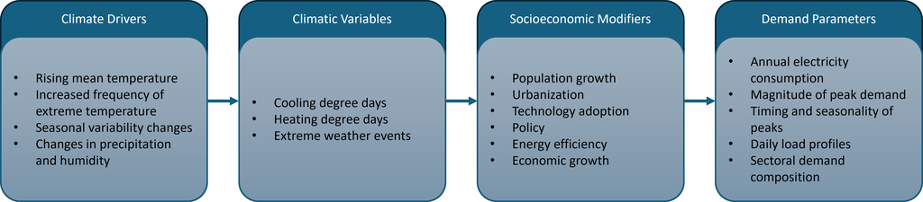

Figure 1. Conceptual link between climate drivers and demand parameters

### Seasonal variations

However, while winters are projected to be warmer, the demand responses are more variable. Romitti and Sue Wing (2022) introduced a classification of demand response profiles: a “V”-shaped response which is common in mid-latitude temperate cities such as those in North America and Europe, where demand increases at both high and low temperatures; an increasing response, where demand rises steadily with temperature, which can be typically shown in tropical cities; and an unresponsive profile, where minimal or no correlation exists between temperature and electricity demand. Pilli-Sihvola et al. (2010) used multivariate regression in Europe to estimate electricity consumption changes and found that Northern and Central Europe will experience reduced heating demand in winter, while Southern Europe will face increased cooling demand and higher costs in summer. This results in increased annual electricity demand in Spain, while it will decrease in Finland, Germany, and France. Although warmer winters are generally expected to reduce heating loads, the widespread adoption of heat pumps and other climate mitigation technologies may lead to increased winter electricity demand due to fuel switching from fossil-based systems to electric heating. Wood et al. (2015) analyzed how climate change could flatten winter peaks while enhancing summer peaks in the United Kingdom, suggesting that infrastructure planning should shift from winter-dominant to summer-dominant strategies.

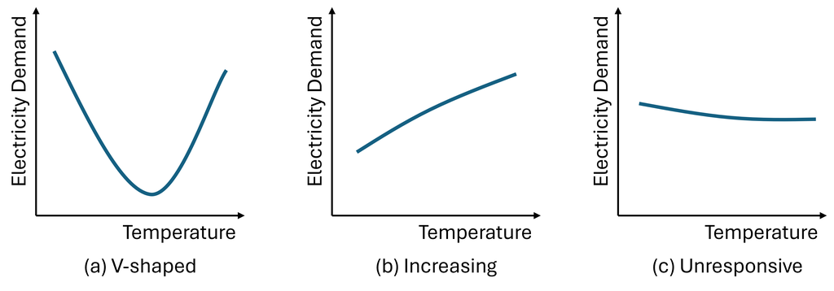

Figure 2. Typical patterns of temperature responses

### Regional variations

The impacts of climate change on electricity demand show considerable regional heterogeneity, influenced by geographic location, climatic baseline, economic development, and infrastructure characteristics. A clear latitudinal pattern exists: countries at lower latitudes are projected to have higher increases in electricity demand for cooling, while higher latitude regions may observe mixed outcomes due to the opposing effects of warmer winters and hotter summers. Similar to the Romitti and Sue Wing (2022)’s classification, Hu et al. (2024) analyzed Temperature Response Functions (TRFs) across Europe by fitting the relationship between electricity demand and temperature to three types of curves: a linear decreasing curve for Northern European countries, a linear curve with a horizontal segment for cold and intermediate climate countries, and a V-shaped curve with a comfort zone for intermediate or warm countries, where both heating and cooling demands are affected.

Regional variations in electricity demand due to climate change across Japan show a clear dependency on latitude (Hiruta et al. (2022)) Northern regions, such as Hokkaido and Tohoku, will experience decreased annual electricity demand owing to reduced heating needs, whereas southern regions from Tokyo to Okinawa will see increased consumption due to extended cooling requirements. Transition zones near the boundary of the northern and southern regions present a balance between reduced heading and increased cooling demands, while these transition zones are shifting northward as climate warming continues. McFarland et al. (2015) also confirmed a decrease in HDD in the northern US, while the increase of CDD is significant in the southern US.

In tropical regions, where average temperatures are already high, even modest increases in temperature can trigger substantial rises in electricity use. Bonkaney et al. (2023) found that rising temperatures will affect electricity demand across all warming levels due to increasing air conditioning needs, with low adaptive capacity exacerbating system stress in Niger. De Cian and Sue Wing (2019) projected larger increases in energy consumption, primarily driven by higher frequency of extreme temperatures and the resulting increased cooling demand. However, in temperate regions, impacts on demand are mixed, varying based on local climate and socioeconomic conditions, as demand can either increase or decrease depending on local climate and geographic incidence of climate change (De Cian and Sue Wing (2019)).

### Sectoral variations

Climate change impacts electricity demand across sectors in different ways due to sector-specific end-use patterns, varying weather sensitivities, and adaptive capacities. Therefore, understanding differences in electricity demand patterns across sectors is essential for ensuring grid resilience under changing climate conditions.

In the residential sector, electricity demand is particularly sensitive to temperature fluctuations, primarily due to the use of heating and cooling appliances to meet residents’ comfort expectations, which increase faster than the climate is changing (Wood et al. (2015)). De Cian and Sue Wing (2019) found that temperate regions, warming reduces heating needs, resulting in lower electricity consumption, especially in households using electricity-based heating systems, such as heat pumps. However, in tropical and warmer temperate zones, the demand for space cooling increases substantially with rising temperatures and humidity levels, leading to a net increase in electricity use in residential buildings. Berardi and Jafarpur (2020) emphasized that while heating energy use intensity may decline by 18-33%, cooling energy user intensity could rise by as much as 126% by 2070 in Canadian buildings.

The commercial sector is also highly climate-sensitive, primarily due to its dependence on heating, ventilating, and air conditioning (HVAC) systems. Taseska et al. (2012) projected that under a warmer climate scenario, commercial electricity demand for cooling would increase, especially during peak summer periods, while the reduction in heating demand would be relatively minor. Véliz et al. (2017) showed that commercial electricity demands would increase, driven not only by higher consumption but also by rising electricity prices. This suggests that the commercial sector faces both quantity- and price-based vulnerabilities under climate change.

The industrial sector shows more heterogeneous responses. Its demand is generally less directly related to air temperature, but certain processes, particularly those requireing climate-controlled environments, are affected by heat. Shaik (2024) showed that electricity demand in the industrial sector remains relatively price-inelastic and shows modest temperature sensitivity compared to other sectors. However, long-term changes in the demand may emerge through indirect pathways, such as workforce comfort requirements, advances in technology, or regulatory standards.

In the transportation sector, electricity demand is currently limited as the sector remains largely dependent on petroleum. However, with increasing electrification of transport systems, future electricity demand is expected to rise significantly (De Cian and Sue Wing (2019)). Shaik (2024) also noted that while the sector’s electricity use is still low, it is highly responsive to economic and price signals, suggesting future variability under combined climate and market pressures.

## Methodologies for assessing climate change impacts

### Climate data

Climate data is essential for the electricity demand impact assessments under climate change. These data are primarily sourced from Global Climate Models (GCMs), which simulate the Earth’s climate system based on physical laws and boundary conditions. GCMs provide long-term projections of atmospheric variables such as temperature and precipitation, which are critical inputs to electricity demand models, especially in studies focusing on temperatrue-sensitive loads like heating and cooling.

Despite the advances in climate data usage, the literature reveals several challenges and limitations. First, the choice of climate models and RCPs is not always clearly justified or consistent across studies, making comparative assessment difficult. Second, biases in raw climate model outputs can distort demand projections if not corrected or validated using observations. Third, the integration of climate data with energy system models often lacks explicit treatment of uncertainty. Fonseca et al. (2019) noted that climate variables alone explain a limited portion of electricity demand variability as socioeconomic, behavioral, and technological factors may play considerable roles. Additionally, while many studies have applied a single or limited number of climate models, ensemble approaches or various combinations of GCMs and RCMs, as used by Reyna and Chester (2017), Auffhammer et al. (2017), Lipson et al. (2019), Fonseca et al. (2019), Chidiac et al. (2022), Lee and Dessler (2022), and Bonkaney et al. (2023), are therefore essential to improve the robustness of results.

## Downscaling methods

Given that GCMs operate at relatively coarse spatial resolutions (typically 100-250 km), their outputs are often inadequate for regional scale modeling. Because electricity planning is typically sensitive to finer-scale temperature variations, it is essential that climate inputs local meteorological conditions with sufficient detail. To address this, two primary categories of downscaling techniques are widely applied in the literature: statistical downscaling and dynamical downscaling.

Statistical downscaling establishes empirical relationships between large-scale GCM variables and local climate observations, using historical data as a training base. These methods are computationally efficient and have been widely used where computational resources or high-resolution models are limited. For example, Berardi and Jafarpur (2020) employed CCWorldWeatherGen and WeatherShift™ tools to statistically downscale GCMs and generated site-specific future weather data in Canada. Similarly, Fonseca et al. (2019) and Auffhammer et al. (2017) applied the Multivariate Adaptive Constructed Analogs (MACA) method to statistically downscale CMIP5 GCM projections for United States. The resulting high-resolution weather data were used to simulate changes in electricity demand profiles under a warming climate. Trotter et al. (2016) also used trend-preserving statistical downscaling method to estimate climate-induced changes across Brazil.

In contrast, dynamical downscaling embeds higher-resolution Regional Climate Models (RCMs) within GCMs to explicitly simulate regional climate processes. This approach is particularly beneficial for capturing terrain-driven weather dynamics and localized extremes. Within the North American COPRDEX (NA-CORDEX), Chidiac et al. (2022) applied multiple RCMs including CRCM5, RCA4, RegCM4, WRF, CanRCM4, and HIRHAM5 driven by GCMs like HadGEM2-ES, CanESM2, MPI-ESM-LR, MPI-ESM-MR. EC-EARTH, and GFDL-ESM2M, to project changes in building-level heating and cooling demands in Ontario. Similarly, Hu et al. (2024) used the ERMO2009 RCM under the EURO-CORDEX project to model electricity demand changes across European countries, providing spatially disaggregated insights into future temperature-response dynamics. These dynamical approaches offer more physically consistent outputs than statistical methods while a higher computational cost is required.

Nevertheless, dynamical downscaling is not without limitations. Bias correction is typically necessary because RCM outputs may deviate from observed climatology. Moreover, the selection of GCM-RCM combinations can introduce additional variability into the projections, as a concern emphasized by Chilkoti et al. (2017). To address this, ensemble approaches using multiple model combinations have become more common to capture the spread of plausible futures and quantify projection uncertainty, although this adds additional computational costs.

## Modeling Frameworks

Climate data such as GCMs and RCMs prepared for the appropriate spatial and temporal resolution are integrated into models that simulate or estimate electricity demand responses to climatic variables. The literature broadly categorizes these models into two groups: empirical models ,which are typically data-driven, and simulation-based models, which are process-oriented or scenario-based. These approaches differ in their methodological structure and are selected based on the availability of data, the spatial and temporal scale of analysis, and the objective of the study or project.

Empirical models typically use regression-based methods to quantify the historical relationship between electricity demand and weather variables, mostly temperature. Auffhammer and Aroonruengsawat (2011) used a simple log-linear regression models to estimate residential demand sensitivity and climate change impacts estimation in California. Fonseca et al. (2019) developed empirical load models based on hourly utility data and downscaled weather variables to simulate load variability under future climate scenarios. Shaik (2024) extended this approach across multiple sectors and climate variables to evaluate sectoral demand elasticity and response behavior in the United States. While empirical models are statistically robust and adequate for retrospective analysis, they are inherently constrained by the historical range of observed conditions and may not fully capture adaptive or nonlinear responses to future extremes.

Simulation models, on the other hand, allow to explore prospective scenarios by embedding climate variables within energy system or physics models. These include tools like EnergyPlus for building-level simulations (as used by Berardi and Jafarpur (2020)) and energy system optimization models such as MARKAL (as applied in Taseska et al. (2012)). Simulation models offer the advantage of flexibility in exploring technological, behavioral and policy adaptations under different emissions and socioeconomic pathways. Lipson et al. (2019) incorporated building-urban-atmosphere interaction models to simulate energy demand responses under urban heat island effects, demonstrating how climate-urban feedbacks can influence spatial energy use patterns. Parkinson and Djilali (2015) modeled electricity system planning under hydro-climatic uncertainty using robust optimization techniques, highlighting the importance of integrating demand and supply-side climate risks.

In practice, demand forecasting is often conducted using end-use approaches (IESO (2025a)), which can be implemented within either an empirical or a simulation-based framework. Empirical end-use models estimate electricity demand by disaggregated categories such as end-use type, sector, or region based on historical consumption patterns and weather variables. In contrast, simulation-based end-use models, which are more common, simulate the behaviour of appliances, buildings, or sectors using physical parameters.

## Demand forecasting

Electricity demand forecasting plays a pivotal role in the planning of power systems, enabling system operators and utilities to balance supply and demand, ensure reliability, and plan future infrastructure investments. As Canada pursues electrification in response to climate policy and decarbonization goals, understanding the methodologies and assumptions underlying demand forecasting becomes more essential. While the interdependence of provincial grids through initiatives such as Canadian Energy Strategy (Natural Resources Canada (2025)) enables robust electricity system planning, demand forecasting in Canada is largely decentralized, with each province or territory adopting methodologies tailored to its own regulatory, climatic, and socioeconomic context. Table 1 presents a brief summary of demand forecasting approaches across Canadian Provinces and Territories.

Table 1. Demand forecasting approaches in Canada

| Province/Territory | Forecasting Organization | Forecasting Approach | Integration of Climate Variables |
| --- | --- | --- | --- |
| Ontario | Independent Electricity System Operator (IESO) | Multivariate econometric model using weather, economic, calendar, and demographic variables | Includes mild, normal, and extreme weather scenarios with monthly and seasonal normalization |
| Québec | Hydro-Québec Distribution | Sector-based forecasting with scenarios for decarbonization and electrification | Uses standard deviations to quantify climate variability and uncertainty in peak demand forecasting |
| Manitoba | Manitoba Hydro | Sector-based forecasting with scenarios for decarbonization and decentralization | Applies 20-year historical normalization for weather |
| British Columbia | BC Hydro | Long-term load forecasting incorporating electrification and climate policies | Considers weather-sensitive demand indirectly |
| Alberta | Alberta Electric System Operator (AESO) | Scenario-based forecasting using macroeconomic and electrification pathways | Scenarios reflect sector-specific electrification and decarbonization |
| Saskatchewan | SaskPower | Embedded within broader energy planning with economic and demographic drivers | Forecasting details regarding climate variables are not publicly disclosed |
| Nova Scotia | Nova Scotia Power | Scenario-based IRP including DSM and electrification scenarios | Policy-driven electrification scenarios |
| New Brunswick | NB Power | Sector-based, scenario-driven IRP with electrification and DSM assumptions | Policy and decarbonization driven |
| Newfoundland and Labrador | Newfoundland and Labrador Hydro (NL Hydro) | Econometric and scenario-based forecasting with industrial and electrification sensitivities | Electrification scenarios considered |
| Prince Edward Island | Maritime Electric | Annual load forecast incorporating space heating, electrification, and DSM programs | Historical trends and electrification patterns considered |
| Yukon | Yukon Energy | Historical growth and electrification trends; focus on winter peak and capacity | Focus on electrification and historical peak trends |
| Northwest Territories | Northwest Territories Power Corporation (NTPC) | Zone-specific, customer-class based forecasting using historical data | Based on historical data |
| Nunavut | Qulliq Energy Corporation (QEC) | Infrastructure and housing-based forecasting aligned with capital plans | Forecasting details regarding climate variables are not publicly disclosed |

### Methodological approaches

In Ontario, the demand forecasting methodology is developed and maintained by the Independent Electricity System Operator (IESO, IESO (2024)). The IESO applies a two-stage approach to electricity demand forecasting. For the medium-term horizon, it uses a multivariate econometric model that establishes statistical relationships between electricity demand and a set of explanatory variables like weather, economic, and demographic factors. The model is structured to simulate hourly electricity demand at both provincial and zonal levels, reflecting the operational needs of the bulk power system. Specifically, the explanatory variables include weather inputs (e.g., temperature, dew point, cloud cover, and wind speed), calendar effects (e.g., weekends, holidays, and daylight duration), economic and demographic conditions (e.g., population and employment). Forecasts also account for embedded generation, load modifiers, conservation acts, and large step loads. The IESO issues demand forecasts under two main scenarios: firm demand and planned demand. Firm demand, which is used for planning and operating the power system, includes demands committed through the connection assessment process, while planned demand adds potential loads with less certainty to reflect future risk. These forecasts support long-term planning, which employs an End-Use Forecasting (EUF) model, which is an end-use level basis simulation model (IESO (2025b)). This model disaggregates demand by residential, commercial, and industrial sectors in 10 IESO zones. The EUF frameworks is modular and includes components such as market segmentation, energy usage, customer growth, equipment choice and scenario forecasting. The modeling framework supports infrastructure investments and resource adequacy. While weather normalization is applied using historical data to generate mild, normal, and extreme demand scenarios, climate change impacts are indirectly considered through scenario development and assumptions on technology adoption and demand-side management, rather than through direct integration of future climate projections into the demand model.

Manitoba Hydro also forecasts electricity demand using a sector-based approach (Manitoba Hydro (2024)). Residential, commercial, and industrial customer classes are forecasted separately based on historical energy use per customer, customer counts, and expected trends. In the recent plan (Manitoba Hydro (2023)), climate change is embedded in demand forecasting primarily through the development of scenarios that reflect varying paces of decarbonization and decentralization. These scenarios are not forecasts, but structured representations of possible energy futures based on different assumptions for key variables such as EV adoption, space heating technologies, economic growth, and customer self-generation. In other words, although climate variables such as temperature changes or extreme weather events are not explicitly accounted for in the demand module, the forecasting model incorporates climate policy and technological adoption as indirect drivers of demand transformation.

In other provinces such as Alberta, Saskatchewan, Nova Scotia, and New Brunswick, demand forecasting is typically scenario-based and integrated into long-term system or resource planning frameworks. Alberta Electric System Operator (AESO) employs detailed scenario analysis in its Long-Term Outlook (LTO), using macroeconomic projections and sector-specific electrification pathways to explore a range of futures, including high electrification and early decarbonization scenarios. The forecasts are built on bottom-up modelling, incorporating third-party inputs, technology assumptions, and stakeholder engagement to ensure policy-aligned projections and grid adequacy over a 20-year horizon (AESO (2024a), AESO (2024b)). Similarly, New Brunswick’s NB Power constructs scenario-based forecasts in its Integrated Resource Plan (IRP), which combines residential, general service, and industrial load projections with assumptions around electrification, demand-side management (DSM), and major infrastructure investments such as small modular reactors and hydro refurbishment (New Brunswick Power Corporation (2023)). Nova Scotia Power applies scenario analysis in its IRP to reflect electrification, DSM, and system integration with surrounding jurisdictions (Nova Scotia Power (2020)). Saskatchewan’s SaskPower does not publicly disclose forecasting details, but demand forecasting is embedded within broader energy planning and supports long-term infrastructure decision (SaskPower (2024)).

In Newfoundland and Labrador, Newfoundland and Labrador Hydro (NL Hydro) is responsible for developing the long-term electricity demand forecast for the Island and Labrador Interconnected Systems. The forecasting methodology uses a combination of econometric models, historical trends, and known future load additions to estimate annual energy and peak demand over a 10-year planning horizon. Key forecasting inputs include provincial economic forecasts, demographic trends, federal and provincial policies and programs, electrification, and industrial customer load growth. In addition, NL Hydro develops multiple planning scenarios to address uncertainties in demand forecast and reliability (Newfoundland Labrador Hydro (2024)). In Prince Edward Island, Maritime Electric conducts demand forecasting as part of its Integrated System Plan (Maritime Electric (2020)). The demand forecast is updated annually to inform generation, energy supply, and transmission system planning. Key drivers of the demand forecast includes space heating, anticipated electrification, and DSM programs.

In Canada’s territories, demand forecasting methodologies are shaped by localized constraints and off-grid characteristics. Yukon Energy projects future demand based on historical load growth, electrification trends, and anticipated industrial activity. Its 2025-2030 plan emphasizes peak demand forecasting, especially in winter, and considers the effects of space heating electrification and new construction on capacity requirements (Yukon Energy Corporation (2025)). The Northwest Territories Power Corporation uses zone-specific historical electricity use and customer class counts to establish near-term forecasts (Northwest Territories Power Corporation (2024)). Qulliq Energy Corporation, serving Nunavut, relies on capital planning alignment with the Government of Nunavut to project electricity demand growth. Load forecasts are developed by tracking government infrastructure expansions, housing development, and municipal growth, primarily to support diesel plant upgrade planning rather than long-term energy system planning (Qulliq Energy Corporation (2023)).

### Forecasting drivers

Electricity demand forecasting across Canadian provinces is driven by a set of common factors that are broadly consistent, although the implementation and emphasis of each factor may differ depending on regional contexts. These common drivers include population and economic growth, weather conditions, electrification trends, and the impacts of energy efficiency and demand-side management programs.

Other provinces show similar influences with context-specific emphases. In Alberta, the AESO attributes both short- and long-term load growth to macroeconomic trends, oil sands development, and emerging sectors such as hydrogen production and data centres. Electrification of buildings, transportation, and heavy industry is projected to significantly increase winter peak demand especially under high electrification scenario (AESO2024). Saskatchewan’s recent peak demand records are attributed to a combination of population growth, economic expansion, and the influence of cold weather, which emphasizes the province’s exposure to space heating requirements (SaskPower (2024)). In Nova Scotia, NS Power includes population, economic activity, and customer-class load growth within scenario-based projections. Electrification trends, particularly in heating and transport, along with DSM achievements and regional integration opportunities, play a critical role in shaping long-term load expectations (Nova Scotia Power (2020)). New Brunswick’s IRP similarly identifies electrification of heating and transportation, DSM uptake, and policy constraints as integral to the load forecast, with distinct scenarios used to assess electrification pace and technology deployment (New Brunswick Power Corporation (2023)).

Electrification of space heating, transportation, and industrial activity is also identified as a major long-term driver of demand forecasting. In Ontario, the IESO projects that system-level net annual energy demand will increase by 75% by 2050 and the average compound annual growth rate will be 2.2%, driven primarily by electrification, such as transportation (e.g., EVs and rail), space heating, and industrial fuel switching (IESO (2025a)). Manitoba Hydro includes heat pumps and EV adoption through end-use profiles and sector-specific forecasts. BC Hydro developed contingency scenarios by considering the accelerated electrification scenario, which assumes full implementation of the electrification plan and provincial greenhouse gas reduction targets, leading to significant demand growth (BC Hydro (2023)). In Alberta, the AESO’s high electrification scenario explores rapid EV adoption, widespread building electrification, and industrial fuel switching as key contributors to annualized demand growth of 1.9% over the next two decades (AESO (2024a)). New Brunswick’s pathways to net-zero require widespread adoption of electrified technologies, including space and water heating, EVs, and the retirement or conversion of fossil fuel-based generators (New Brunswick Power Corporation (2023)). Similarly, Nova Scotia Power’s IRP accounts for electrification trajectories across residential and commercial sectors, evaluating demand under low-, mid-, and high-electrification scenarios (Nova Scotia Power (2020)). In PEI, Maritime Electric identifies increased adoption of electric space heating as the primary driver of both energy and peak demand growth. Additionally, housing starts, customer load growth, and anticipated future EV adoption are considered key forecasting inputs (Maritime Electric (2020)).

In the territories, electricity demand forecasting is primarily driven by infrastructure development, space heating requirements, population trends, and emerging electrification. In Yukon, peak demand forecasting emphasizes the growing influence of winter heating loads as homes and businesses shift from propane or diesel to electric heat. Yukon Energy also anticipates load increases from new housing developments and public infrastructure, particularly in the Whitehorse area, where most growth is concentrated (Yukon Energy Corporation (2025)). In the Northwest Territories, forecasting drivers include customer count trends, usage per customer data, and temperature-sensitive loads. Load growth is additionally influenced by electrification of heating and regional economic conditions (Northwest Territories Power Corporation (2024)). In Nunavut, demand forecasts are informed by the capital investment plans, particularly new housing and public facility construction. Electricity demand is expected to rise with expanded community infrastructure and gradual adoption of electric heating in buildings (Qulliq Energy Corporation (2023)).

### Accounting for climate change in demand forecasting

The IESO (IESO (2024)) acknowledges that relying solely on historical weather data is insufficient under changing climate and has committed to developing climate-informed weather variables and analytical tools for future forecasts. These enhancements aim to better incorporate climate change-induced uncertainties in demand forecasting. While current forecasts use historical weather to generate normal, mild, and extreme scenarios, the IESO recognizes the limitation of this approach in a warming climate. Its long-term demand forecast is built using an end-use model that captures temperature sensitive loads such as heating and cooling from electrified technologies like heat pumps and EVs. These are reflected through hourly load profiles that incorporate seasonal and diurnal variability but are not yet dynamically adjusted based on projected climate conditions, for example, future HDD/CDD from GCMs or RCMs. The 2024 amendment to Ontario’s Electricity Act further reinforces IESO’s mandate to promote electrification and efficiency measures, supporting broader decarbonization objectives while introducing new uncertainties related to policy-driven demand shifts. These efforts underscore IESO’s commitment to evolving its methodology to reflect both transitional and physical climate risks.

In Manitoba Hydro’s demand forecasting (Manitoba Hydro (2024)), climate considerations are indirectly embedded through weather normalization and scenario-based electrification modelling, but explicit integration of future climate change projections remains limited. It applies a normal weather adjustment, defined as a 20-year historical average, to remove the influence of short-term weather variability from historical load data used in model calibration. This adjusted baseline is used to estimate temperature-sensitive loads such as space heating and cooling. Additionally, forecasts are built using hourly end-use profiles that reflect heating and cooling loads, including the adoption of electrified technologies like heat pumps and EVs. These end-use models incorporate seasonal and diurnal variability, capturing how temperature-related usage patterns will evolve with increased electrification. However, the load forecast does not explicitly incorporate climate change projections, such as those from GCMs, nor does it adjust future HDD and CDD based on projected warming trends. Although electrification scenarios reflect potential policy-driven adoption of heat pumps and air conditioning, these are typically modelled without changing climate conditions. As such, the forecasts do not account for chronic climate shifts (e.g., rising average temperature) or acute events (e.g., heatwaves) that could reshape the seasonal and peak demand profiles over time.

BC Hydro also recognizes the relevance of climate change in electricity demand forecasting, particularly in the context of long-term planning. However, the direct integration of climate data remains minimal (BC Hydro (2023)). The plan indicated that climate change is expected to reduce long-term energy and capacity demand by approximately 2% due to warmer winters and reduced space heating needs, while the decline due to changing climate is less significant compared to other factors. Electrification trends driven by climate policy goals have been more important to demand growth scenarios, such as the Accelerated Electrification Scenario. These scenarios reflect the policy response to climate change, not the physical impacts of the changing climate itself. For example, anticipated demand increases are modelled as part of these potential pathways. This represents an indirect response to climate change through decarbonization strategy, while demand-side impacts of climate change are not directly reflected.

SaskPower’s 2023-24 Annual Report (SaskPower (2024)) discusses climate change in terms of emissions reduction and net-zero planning, but does not indicate that climate change is directly integrated into demand forecasting. Instead, the utility focuses on generation-side adaptation and system resilience through renewable integration, battery storage, and fuel-switching strategies. It is acknowledged that electrification of space heating and transport has been increased, but it is not accounted for the demand forecasts based on changing climate variables such as fewer HDDs or more CDDs. Nova Scotia Power’s 2020 IRP (Nova Scotia Power (2020)) addresses climate change through decarbonization policy scenarios and electrification of heating and transportation, but does not incorporate future climate projections. Although demand-side measures such as DSM and distributed generation are included, the IRP scenarios focus on emission reductions and policy trajectories, not on physical climate impacts like altered heating or cooling demands due to long-term temperature trends.

New Brunswick’s 2023 IRP takes a more explicit stance on climate change as a driver of both policy and system transformation. While future weather patterns are not directly embedded in demand forecasts, the province’s Clean Electricity Regulation and 2050 net-zero targets significantly shape demand pathways. However, like other jurisdictions, the IRP does not yet apply modified temperature trends in their HDDs and CDDs to adjust demand forecasts (New Brunswick Power Corporation (2023)). In Newfoundland and Labrador and Prince Edward Island, climate variables are considered in demand forecasts primarily through the electrification trends. NL Hydro’s load forecasting scenarios account for different levels of electrification in space heating and transportation but do not incorporate climate-adjusted temperature projections (Newfoundland Labrador Hydro (2024)). Similarly, Maritime Electric’s forecasting for PEI reflects increased adoption of electric heating as a key demand driver. However, the forecasts do not explicitly integrate future climate-driven temperature changes or extreme weather scenarios, relying instead on historical load trends (Maritime Electric (2020)).

In the territories, climate change is also acknowledged more as a contextual stressor than a variable embedded in quantitative forecasting models. Yukon Energy’s plan highlights the challenges of winter reliability under increasing electricity demand from heating electrification but does not include climate-adjusted temperature baselines (Yukon Energy Corporation (2025)). Demand forecasts in the Northwest Territories and Nunavut are also based on historical data, known infrastructure expansion, or community-level developments, but no forward-looking climate data (Northwest Territories Power Corporation (2024), Qulliq Energy Corporation (2023)).

In sum, while the relevance of climate change to electricity demand is well recognized, it is primarily reflected as a policy driver through electrification scenarios rather than as a physical driver of temperature-sensitive electricity use. Most provinces and territories continue to rely on historical weather data or basic normalization techniques, without dynamically adjusting demand based on projected temperature trends or extreme weather risks. To enhance forecasting accuracy and resilience in the context of a changing climate, it is recommended to gradually incorporate climate change information; for example, by using climate-adjusted temperature variables such as updated HDDs and CDDs, or by integrating outputs from climate model (e.g., GCMs or RCMs) into scenario development. This progression would help ensure that electricity planning and design remain robust under a changing climate.

## Workshops decision-making challenges

This paragraph refers to one of the applications presented during the workshop in Ontario on integrating climate change into demand forecasting.

Demand forecasting is primarily shaped by the [North American Electric Reliability Corporation (NERC)](https://www.nerc.com/pa/Stand/Pages/ReliabilityStandardsOntario.aspx) requirement to maintain a five-year planning reserve margin. As a result, two forecasting horizons are considered: medium-term (11 days to 2 years) and long-term (2 to 20 years). The medium-term is statistically based on historical data (31 years) while the long term planning is physically based (exemple buildings sized for heating) with plans to incorporate regression of heating and cooling degree days (statitically based) in the future. The load forecasting model incorporates historical hourly normals for dry bulb temperature, cloud cover, wind speed, dew point and global horizontal irradiance across ten geographic zones in the province. There is plan to incorporate relative humidity and temperature (heating degree days and cooling degree days) in the forecast.

The main sources for these datasets are Environment Canada and external consultants (wind speed and global horizontal irradiance). Climate data is validated by comparing the model’s outputs with historical load data, ensuring that the forecasts align with observed patterns.

Demand forecasts inform a wide range of activities in the energy sector, including resource and transmission planning, budget submissions, financial planning, and demand response programs. There are ongoing efforts to incorporate climate change considerations into load forecasting in the near future. Planned enhancements include extending the long-term forecast horizon and integrating climate-adjusted regressions for heating and cooling degree days.

The figure below briefly resumes decision-making challenges faced by professionnals in the demand sector of the electricity system in Canada. These challenges were shared during the workshops held in 2025.

[interactive chart not shown]

## References

AESO, 2024a. AESO 2024 Long‑Term Outlook.

AESO, 2024b. Methodology , Risks and Drivers Load Forecasting Methodology.

Allen, M.R., Fernandez, S.J., Fu, J.S., Olama, M.M., 2016. Impacts of climate change on sub-regional electricity demand and distribution in the southern United States. Nature Energy 1. https://doi.org/10.1038/nenergy.2016.103

Amonkar, Y., Doss-Gollin, J., Farnham, D.J., Modi, V., Lall, U., 2023. Differential effects of climate change on average and peak demand for heating and cooling across the contiguous USA. Communications Earth and Environment 4, 1–9. https://doi.org/10.1038/s43247-023-01048-1

Auffhammer, M., Aroonruengsawat, A., 2011. Simulating the impacts of climate change, prices and population on California’s residential electricity consumption. Climatic Change 109, 191–210. https://doi.org/10.1007/s10584-011-0299-y

Auffhammer, M., Baylis, P., Hausman, C.H., 2017. Climate change is projected to have severe impacts on the frequency and intensity of peak electricity demand across the United States. Proceedings of the National Academy of Sciences of the United States of America 114, 1886–1891. https://doi.org/10.1073/pnas.1613193114

BC Hydro, 2023. [2021 Integrated Resource Plan (2023 Update)](https://www.bchydro.com/content/dam/BCHydro/customer-portal/documents/corporate/regulatory-planning-documents/integrated-resource-plans/current-plan/integrated-resource-plan-2021.pdf).

Berardi, U., Jafarpur, P., 2020. Assessing the impact of climate change on building heating and cooling energy demand in Canada. Renewable and Sustainable Energy Reviews 121, 109681. https://doi.org/10.1016/j.rser.2019.109681

Bonkaney, A.L., Abiodun, B.J., Sanda, I.S., Balogun, A.A., 2023. Potential impact of global warming on electricity demand in Niger. Climatic Change 176. https://doi.org/10.1007/s10584-023-03513-4

Burillo, D., Chester, M.V., Pincetl, S., Fournier, E.D., Reyna, J., 2019. Forecasting peak electricity demand for Los Angeles considering higher air temperatures due to climate change. Applied Energy 236, 1–9. https://doi.org/10.1016/j.apenergy.2018.11.039

Chidiac, S.E., Yao, L., Liu, P., 2022. Climate Change Effects on Heating and Cooling Demands of Buildings in Canada. CivilEng 3, 277–295. https://doi.org/10.3390/civileng3020017

Chilkoti, V., Bolisetti, T., Balachandar, R., 2017. Climate change impact assessment on hydropower generation using multi-model climate ensemble. Renewable Energy 109, 510–517. https://doi.org/10.1016/j.renene.2017.02.041

De Cian, E., Sue Wing, I., 2019. Global Energy Consumption in a Warming Climate. Environmental and Resource Economics 72, 365–410. https://doi.org/10.1007/s10640-017-0198-4

Dessler, A.E., 2025. Climate Change Increases Energy Demand and Cost in Texas. Weather, Climate, and Society 17, 153–160. https://doi.org/10.1175/WCAS-D-24-0057.1

Dirks, J.A., Gorrissen, W.J., Hathaway, J.H., Skorski, D.C., Scott, M.J., Pulsipher, T.C., Huang, M., Liu, Y., Rice, J.S., 2015. Impacts of climate change on energy consumption and peak demand in buildings: A detailed regional approach. Energy 79, 20–32. https://doi.org/10.1016/j.energy.2014.08.081

Emodi, N.V., Chaiechi, T., Alam Beg, A.B.M.R., 2018. The impact of climate change on electricity demand in Australia. Energy and Environment 29, 1263–1297. https://doi.org/10.1177/0958305X18776538

Fonseca, F.R., Craig, M., Jaramillo, P., Berge, M., Severnini, E., Loew, A., Zhai, H., Cheng, Y., Nijssen, B., Voisin, N., Yearsley, J., 2021. Effects of climate change on capacity expansion decisions of an electricity generation fleet in the southeast U.S. Environmental Science and Technology 55, 2522–2531. https://doi.org/10.1021/acs.est.0c06547

Fonseca, F.R., Jaramillo, P., Bergés, M., Severnini, E., 2019. Seasonal effects of climate change on intra-day electricity demand patterns. Climatic Change 154, 435–451. https://doi.org/10.1007/s10584-019-02413-w

Garrido-Perez, J.M., Barriopedro, D., García-Herrera, R., Ordóñez, C., 2021. Impact of climate change on Spanish electricity demand. Climatic Change 165, 1–18. https://doi.org/10.1007/s10584-021-03086-0

Hiruta, Y., Gao, L., Ashina, S., 2022. A novel method for acquiring rigorous temperature response functions for electricity demand at a regional scale. Science of the Total Environment 819. https://doi.org/10.1016/j.scitotenv.2021.152893

Hu, W., Scholz, Y., Yeligeti, M., Deng, Y., Jochem, P., 2024. Future electricity demand for Europe: Unraveling the dynamics of the Temperature Response Function. Applied Energy 368, 123387. https://doi.org/10.1016/j.apenergy.2024.123387

IESO, 2025b. Annual Planning Outlook - Demand Forecast Methodology (No. April).

IESO, 2025a. Annual Planning Outlook - Ontario’s electricity system needs: 2026-2050.

IESO, 2024. Methodology to Perform the Reliability Outlook 1–50.

Klein, D.R., Olonscheck, M., Walther, C., Kropp, J.P., 2013. Susceptibility of the European electricity sector to climate change. Energy 59, 183–193. https://doi.org/10.1016/j.energy.2013.06.048

Lee, J., Dessler, A.E., 2022. The Impact of Neglecting Climate Change and Variability on ERCOT’s Forecasts of Electricity Demand in Texas. Weather, Climate, and Society 14, 499–505. https://doi.org/10.1175/WCAS-D-21-0140.1

Lipson, M.J., Thatcher, M., Hart, M.A., Pitman, A., 2019. Climate change impact on energy demand in building-urban-atmosphere simulations through the 21st century. Environmental Research Letters 14. https://doi.org/10.1088/1748-9326/ab5aa5

Manitoba Hydro, 2024. [Fiscal 2026 to 2028 General Rate Application. Appendix 4.1 - 2024 Electric Load Forecast](https://www.hydro.mb.ca/docs/regulatory_affairs/pdf/electric/gra_2026_2028/04-1_appendix_4-1_2024_electric_load_forecast.pdf).

Manitoba Hydro, 2023. [2023 Integrated Resource Plan](https://www.hydro.mb.ca/docs/corporate/irp/irp-2023-integrated-resource-plan.pdf) (No. July).

Maritime Electric, 2020. 2020 Integrated System Plan.

McFarland, J., Zhou, Y., Clarke, L., Sullivan, P., Colman, J., Jaglom, W.S., Colley, M., Patel, P., Eom, J., Kim, S.H., Kyle, G.P., Schultz, P., Venkatesh, B., Haydel, J., Mack, C., Creason, J., 2015. Impacts of rising air temperatures and emissions mitigation on electricity demand and supply in the United States: a multi-model comparison. Climatic Change 131, 111–125. https://doi.org/10.1007/s10584-015-1380-8

Natural Resources Canada, 2025. [Powering Canada’s Future: A Clean Electricity Strategy](https://natural-resources.canada.ca/energy-sources/powering-canada-s-future-clean-electricity-strategy).

New Brunswick Power Corporation, 2023. 2023 Integrated Resource Plan.

Newfoundland Labrador Hydro, 2024. 2024 Resource Adequacy Plan.

Northwest Territories Power Corporation, 2024. 2024-26 General Rate Application Phase I.

Nova Scotia Power, 2020. 2020 Integrated Resource Plan.

Obringer, R., Nateghi, R., Knee, J., Madani, K., Kumar, R., 2023. Contemporary climate analogs project strong regional differences in the future water and electricity demand across US cities. One Earth 6, 1542–1553. https://doi.org/10.1016/j.oneear.2023.10.004

Parkinson, S.C., Djilali, N., 2015. Robust response to hydro-climatic change in electricity generation planning. Climatic Change 130, 475–489. https://doi.org/10.1007/s10584-015-1359-5

Pilli-Sihvola, K., Aatola, P., Ollikainen, M., Tuomenvirta, H., 2010. Climate change and electricity consumption-Witnessing increasing or decreasing use and costs? Energy Policy 38, 2409–2419. https://doi.org/10.1016/j.enpol.2009.12.033

Qulliq Energy Corporation, 2023. Corporate Plan 2023-2026.

Reyna, J.L., Chester, M.V., 2017. Energy efficiency to reduce residential electricity and natural gas use under climate change. Nature Communications 8. https://doi.org/10.1038/ncomms14916

Romitti, Y., Sue Wing, I., 2022. Heterogeneous climate change impacts on electricity demand in world cities circa mid-century. Scientific Reports 12. https://doi.org/10.1038/s41598-022-07922-w

SaskPower, 2024. Annual Report 2023-24.

Schaeffer, R., Szklo, A.S., Pereira de Lucena, A.F., Moreira Cesar Borba, B.S., Pupo Nogueira, L.P., Fleming, F.P., Troccoli, A., Harrison, M., Boulahya, M.S., 2012. Energy sector vulnerability to climate change: A review. https://doi.org/10.1016/j.energy.2011.11.056

Shaik, S., 2024. Contribution of climate change to sector-source energy demand. Energy 294, 130777. https://doi.org/10.1016/j.energy.2024.130777

Taseska, V., Markovska, N., Callaway, J.M., 2012. Evaluation of climate change impacts on energy demand. Energy 48, 88–95. https://doi.org/10.1016/j.energy.2012.06.053

Trotter, I.M., Bolkesjø, T.F., Féres, J.G., Hollanda, L., 2016. Climate change and electricity demand in Brazil: A stochastic approach. Energy 102, 596–604. https://doi.org/10.1016/j.energy.2016.02.120

Véliz, K.D., Kaufmann, R.K., Cleveland, C.J., Stoner, A.M.K., 2017. The effect of climate change on electricity expenditures in Massachusetts. Energy Policy 106, 1–11. https://doi.org/10.1016/j.enpol.2017.03.016

Wood, F.R., Calverley, D., Glynn, S., Mander, S., Conor, W., Kuriakose, J., Hill, F., Roeder, M., 2015. The impacts of climate change on UK energy demand. Infrastructure Asset Management 2, 107–119. https://doi.org/10.1680/jinam.14.00039

Yukon Energy Corporation, 2025. Building a Resilient and Renewable Energy Future: Chapter 1.

Zachariadis, T., Hadjinicolaou, P., 2014. The effect of climate change on electricity needs - A case study from Mediterranean Europe. Energy 76, 899–910. https://doi.org/10.1016/j.energy.2014.09.001